# R Notebook

rakibul islam prince

```r
library(pacman)
```

```r
str(stroke_data)
```

```
'data.frame':   5110 obs. of  12 variables:
 $ id               : int  9046 51676 31112 60182 1665 56669 53882 10434 27419 60491 ...
 $ gender           : chr  "Male" "Female" "Male" "Female" ...
 $ age              : num  67 61 80 49 79 81 74 69 59 78 ...
 $ hypertension     : int  0 0 0 0 1 0 1 0 0 0 ...
 $ heart_disease    : int  1 0 1 0 0 0 1 0 0 0 ...
 $ ever_married     : chr  "Yes" "Yes" "Yes" "Yes" ...
 $ work_type        : chr  "Private" "Self-employed" "Private" "Private" ...
 $ Residence_type   : chr  "Urban" "Rural" "Rural" "Urban" ...
 $ avg_glucose_level: num  229 202 106 171 174 ...
 $ bmi              : chr  "36.6" "N/A" "32.5" "34.4" ...
 $ smoking_status   : chr  "formerly smoked" "never smoked" "never smoked" "smokes" ...
 $ stroke           : int  1 1 1 1 1 1 1 1 1 1 ...
```

```r
install.packages("binom")
```

```r
library(binom)
```

```r
head(stroke_data,15)
```

|  | id | gender | age | hypertension | heart_disease | ever_married | work_type | Residence_type | avg_glucose_level | bmi | smoking_status | stroke |
| --- | --- | --- | --- | --- | --- | --- | --- | --- | --- | --- | --- | --- |
| 1 | 9046 | Male | 67 | 0 | 1 | Yes | Private | Urban | 228.69 | 36.6 | formerly smoked | 1 |
| 2 | 51676 | Female | 61 | 0 | 0 | Yes | Self-employed | Rural | 202.21 | N/A | never smoked | 1 |
| 3 | 31112 | Male | 80 | 0 | 1 | Yes | Private | Rural | 105.92 | 32.5 | never smoked | 1 |
| 4 | 60182 | Female | 49 | 0 | 0 | Yes | Private | Urban | 171.23 | 34.4 | smokes | 1 |
| 5 | 1665 | Female | 79 | 1 | 0 | Yes | Self-employed | Rural | 174.12 | 24 | never smoked | 1 |
| 6 | 56669 | Male | 81 | 0 | 0 | Yes | Private | Urban | 186.21 | 29 | formerly smoked | 1 |
| 7 | 53882 | Male | 74 | 1 | 1 | Yes | Private | Rural | 70.09 | 27.4 | never smoked | 1 |
| 8 | 10434 | Female | 69 | 0 | 0 | No | Private | Urban | 94.39 | 22.8 | never smoked | 1 |
| 9 | 27419 | Female | 59 | 0 | 0 | Yes | Private | Rural | 76.15 | N/A | Unknown | 1 |
| 10 | 60491 | Female | 78 | 0 | 0 | Yes | Private | Urban | 58.57 | 24.2 | Unknown | 1 |

[output cut: 5 more lines]

data cleaning

```r
stroke_data<-stroke_data %>% filter(!is.na(stroke_data))
```

[output not shown]

```r
#removing all rows having "N/A" values
clean_stroke_data<-stroke_data[!apply(stroke_data=="N/A",1,any),]
```

```r
head(clean_stroke_data,n=15)
```

|  | id | gender | age | hypertension | heart_disease | ever_married | work_type | Residence_type | avg_glucose_level | bmi | smoking_status | stroke |
| --- | --- | --- | --- | --- | --- | --- | --- | --- | --- | --- | --- | --- |
| 1 | 9046 | Male | 67 | 0 | 1 | Yes | Private | Urban | 228.69 | 36.6 | formerly smoked | 1 |
| 3 | 31112 | Male | 80 | 0 | 1 | Yes | Private | Rural | 105.92 | 32.5 | never smoked | 1 |
| 4 | 60182 | Female | 49 | 0 | 0 | Yes | Private | Urban | 171.23 | 34.4 | smokes | 1 |
| 5 | 1665 | Female | 79 | 1 | 0 | Yes | Self-employed | Rural | 174.12 | 24 | never smoked | 1 |
| 6 | 56669 | Male | 81 | 0 | 0 | Yes | Private | Urban | 186.21 | 29 | formerly smoked | 1 |
| 7 | 53882 | Male | 74 | 1 | 1 | Yes | Private | Rural | 70.09 | 27.4 | never smoked | 1 |
| 8 | 10434 | Female | 69 | 0 | 0 | No | Private | Urban | 94.39 | 22.8 | never smoked | 1 |
| 10 | 60491 | Female | 78 | 0 | 0 | Yes | Private | Urban | 58.57 | 24.2 | Unknown | 1 |
| 11 | 12109 | Female | 81 | 1 | 0 | Yes | Private | Rural | 80.43 | 29.7 | never smoked | 1 |
| 12 | 12095 | Female | 61 | 0 | 1 | Yes | Govt_job | Rural | 120.46 | 36.8 | smokes | 1 |

[output cut: 5 more lines]

```r
#keeping only male and females
clean_g_stroke_data<-clean_stroke_data %>%
  filter(gender!="Other")
```

```r
#converting bmi column to numeric
clean_g_stroke_data$bmi<-as.numeric(clean_g_stroke_data$bmi)
str(clean_g_stroke_data)
```

```
'data.frame':   4908 obs. of  12 variables:
 $ id               : int  9046 31112 60182 1665 56669 53882 10434 60491 12109 12095 ...
 $ gender           : chr  "Male" "Male" "Female" "Female" ...
 $ age              : num  67 80 49 79 81 74 69 78 81 61 ...
 $ hypertension     : int  0 0 0 1 0 1 0 0 1 0 ...
 $ heart_disease    : int  1 1 0 0 0 1 0 0 0 1 ...
 $ ever_married     : chr  "Yes" "Yes" "Yes" "Yes" ...
 $ work_type        : chr  "Private" "Private" "Private" "Self-employed" ...
 $ Residence_type   : chr  "Urban" "Rural" "Urban" "Rural" ...
 $ avg_glucose_level: num  229 106 171 174 186 ...
 $ bmi              : num  36.6 32.5 34.4 24 29 27.4 22.8 24.2 29.7 36.8 ...
 $ smoking_status   : chr  "formerly smoked" "never smoked" "smokes" "never smoked" ...
 $ stroke           : int  1 1 1 1 1 1 1 1 1 1 ...
```

```r
bmi_gen<-clean_g_stroke_data %>% select(gender, bmi)
str(bmi_gen)
```

```
'data.frame':   4908 obs. of  2 variables:
 $ gender: chr  "Male" "Male" "Female" "Female" ...
 $ bmi   : num  36.6 32.5 34.4 24 29 27.4 22.8 24.2 29.7 36.8 ...
```

```r
bmi_gen$gender<-as.factor(bmi_gen$gender)
```

```r
str(bmi_gen)
```

```
'data.frame':   4908 obs. of  2 variables:
 $ gender: Factor w/ 2 levels "Female","Male": 2 2 1 1 2 2 1 1 1 1 ...
 $ bmi   : num  36.6 32.5 34.4 24 29 27.4 22.8 24.2 29.7 36.8 ...
```

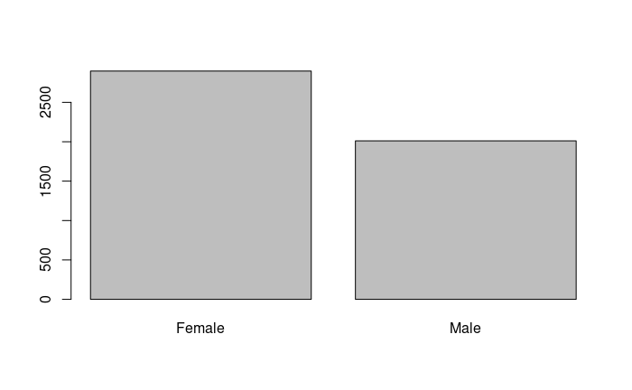

```r
plot(bmi_gen$gender)
```

```r
bmi_mar<- clean_g_stroke_data %>% select(ever_married, bmi)
```

```r
bmi_mar$ever_married<-as.factor(bmi_mar$ever_married)
bmi_mar$bmi<-as.numeric(bmi_mar$bmi)
```

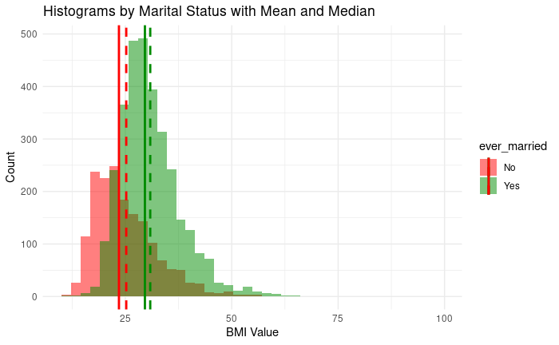

```r
#calculating the mean and the median

mar_mean<-mean(bmi_mar$bmi[bmi_mar$ever_married=="Yes"], na.rm=TRUE)
mar_median<-median(bmi_mar$bmi[bmi_mar$ever_married=="Yes"], na.rm=TRUE)
unmar_mean<-mean(bmi_mar$bmi[bmi_mar$ever_married!="Yes"], na.rm=TRUE)
unmar_median<-median(bmi_mar$bmi[bmi_mar$ever_married!="Yes"], na.rm=TRUE)



#Combine all datasets you want to visualize into a single data frame. This data frame should have one #column with all the data values and another column indicating the source dataset or category for each #value.
df <- data.frame(
  value = c(bmi_mar$bmi[bmi_mar$ever_married=="Yes"], bmi_mar$bmi[bmi_mar$ever_married!="Yes"]),
  category = factor(c(rep("married", length(bmi_mar$bmi[bmi_mar$ever_married=="Yes"])),
                      rep("unmarried", length(bmi_mar$bmi[bmi_mar$ever_married!="Yes"]))))
)


#Use the ggplot() function to initiate the plot. Define which column of the data frame represents the #data values and which one represents the categories. This is typically done using the aes() function.
#For each dataset or category you want to visualize, add a geom_histogram() layer to the plot. Use the #data=subset(df, category=="your_category_name") argument to specify which subset of the data to use #for each histogram.
#To make sure the histograms are distinguishable when overlaid, adjust their transparency with the alpha argument (e.g., alpha=0.5).
p <- ggplot(bmi_mar, aes(x=bmi, fill=ever_married)) +
  geom_histogram(alpha=0.5, position="identity", bins=40) +


  scale_fill_manual(values=c("red", "green4"))+

  geom_vline(aes(xintercept=mar_mean), color="green4", linetype="dashed", size=1, show.legend=TRUE, label="Mean Married") +
  geom_vline(aes(xintercept=mar_median), color="green4", linetype="solid", size=1, show.legend=TRUE, label="Mean Married") +
  geom_vline(aes(xintercept=unmar_mean), color="red", linetype="dashed", size=1, show.legend=TRUE, label="Mean Unmarried") +
  geom_vline(aes(xintercept=unmar_median), color="red", linetype="solid", size=1, show.legend=TRUE, label="Mean Unmarried") +
  theme_minimal() +
  labs(title = "Histograms by Marital Status with Mean and Median", x = "BMI Value", y = "Count")
print(p)
```

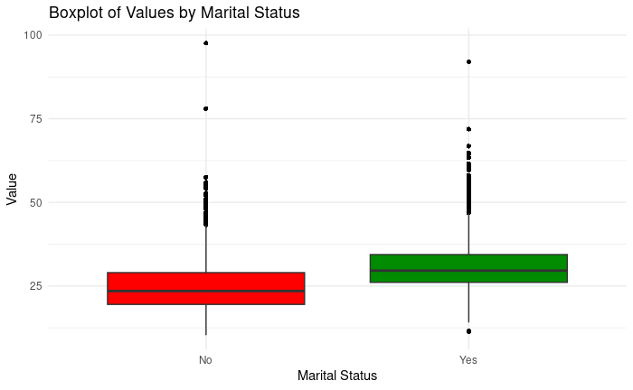

```r
q <- ggplot(bmi_mar, aes(x=ever_married, y=bmi)) +
  geom_boxplot(aes(fill=ever_married), outlier.color="black", outlier.shape=16) +
  labs(title="Boxplot of Values by Marital Status", x="Marital Status", y="Value") +
  theme_minimal() +
  scale_fill_manual(values=c("Yes"="green4", "No"="red")) +  # Manual coloring
  theme(legend.position="none")  # Removing legend since fill color indicates category

print(q)
```

```r
summary(filter(bmi_mar, bmi_mar$ever_married=="Yes"))
```

```
 ever_married      bmi
 No :   0     Min.   :11.30
 Yes:3204     1st Qu.:26.10
              Median :29.60
              Mean   :30.85
              3rd Qu.:34.40
              Max.   :92.00
```

```r
summary(filter(bmi_mar, bmi_mar$ever_married=="No"))
```

```
 ever_married      bmi
 No :1704     Min.   :10.30
 Yes:   0     1st Qu.:19.50
              Median :23.50
              Mean   :25.22
              3rd Qu.:29.00
              Max.   :97.60
```

```r
summary(clean_g_stroke_data)
```

```
       id           gender               age         hypertension     heart_disease     ever_married
 Min.   :   77   Length:4908        Min.   : 0.08   Min.   :0.00000   Min.   :0.00000   Length:4908
 1st Qu.:18602   Class :character   1st Qu.:25.00   1st Qu.:0.00000   1st Qu.:0.00000   Class :character
 Median :37580   Mode  :character   Median :44.00   Median :0.00000   Median :0.00000   Mode  :character
 Mean   :37060                      Mean   :42.87   Mean   :0.09189   Mean   :0.04951
 3rd Qu.:55182                      3rd Qu.:60.00   3rd Qu.:0.00000   3rd Qu.:0.00000
 Max.   :72940                      Max.   :82.00   Max.   :1.00000   Max.   :1.00000
  work_type         Residence_type     avg_glucose_level      bmi        smoking_status         stroke
 Length:4908        Length:4908        Min.   : 55.12    Min.   :10.30   Length:4908        Min.   :0.00000
 Class :character   Class :character   1st Qu.: 77.07    1st Qu.:23.50   Class :character   1st Qu.:0.00000
 Mode  :character   Mode  :character   Median : 91.68    Median :28.10   Mode  :character   Median :0.00000
                                       Mean   :105.30    Mean   :28.89                      Mean   :0.04258
                                       3rd Qu.:113.50    3rd Qu.:33.10                      3rd Qu.:0.00000
                                       Max.   :271.74    Max.   :97.60                      Max.   :1.00000
```

```r
clean_g_stroke_data$hypertension<-as.factor(clean_g_stroke_data$hypertension)
clean_g_stroke_data$heart_disease<-as.factor(clean_g_stroke_data$heart_disease)
clean_g_stroke_data$stroke<-as.factor(clean_g_stroke_data$stroke)
```

```r
install.packages("cowplot")
```

```r
library(cowplot)
```

```r
data<-clean_g_stroke_data
dist_plot<-function(param){
  #calculating the mean and the median
  #people who had a stroke
  mar_mean<-mean(data[[param]][data$stroke==1], na.rm=TRUE)
  mar_median<-median(data[[param]][data$stroke==1], na.rm=TRUE)
  #people who did not have a stroke
  unmar_mean<-mean(data[[param]][data$stroke==0], na.rm=TRUE)
  unmar_median<-median(data[[param]][data$stroke==0], na.rm=TRUE)


  #histogram by stroke status(e.g. age distribution by stroke)
  hist <- ggplot(data, aes(x=eval(parse(text=param)), fill=stroke)) +
    geom_histogram(alpha=0.5, position="identity", bins=40) +
    scale_fill_manual(values=c("purple", "blue"))+
    geom_vline(aes(xintercept=mar_mean), color="blue", linetype="dashed", size=1, show.legend=TRUE, label="Mean Married") +
    geom_vline(aes(xintercept=mar_median), color="blue", linetype="solid", size=1, show.legend=TRUE, label="Mean Married") +
    geom_vline(aes(xintercept=unmar_mean), color="purple", linetype="dashed", size=1, show.legend=TRUE, label="Mean Unmarried") +
    geom_vline(aes(xintercept=unmar_median), color="purple", linetype="solid", size=1, show.legend=TRUE, label="Mean Unmarried") +
    theme_minimal() +
    labs( x = param, y = "freq")


  box <- ggplot(data, aes(x=stroke, y=eval(parse(text=param)))) +
  geom_boxplot(aes(fill=stroke), outlier.color="black", outlier.shape=16) +
  labs( x="Stroke", y=param) +
  theme_minimal() +
  scale_fill_manual(values=c("1"="blue", "0"="purple")) +  # Manual coloring
  theme(legend.position="none")  # Removing legend since fill color indicates category

  return(plot_grid(hist,box))
}
```

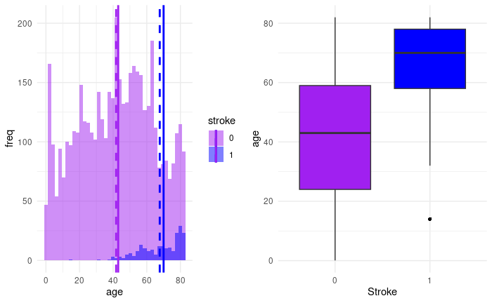

```r
dist_plot("age")
```

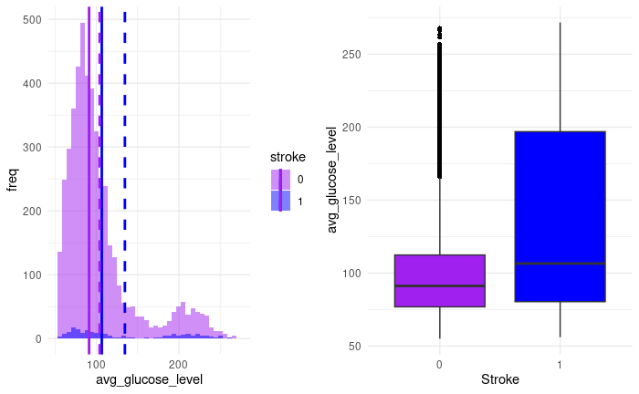

```r
dist_plot("avg_glucose_level")
```

```r
ratio_barpplot<-function(x){
  # here at first x will be in character format.
  barplt<-data %>% select(stroke, x, gender) %>%
            group_by(stroke,param=eval(parse(text=x))) %>% #parsing x from text to act as a column name
            summarise(count = length(gender)) %>%
            group_by(stroke) %>%
            mutate(ratio=round((count*100)/sum(count),1)) %>%
            ggplot(aes(x=stroke, y=ratio, fill=param)) +
            geom_bar(stat="identity") +
            scale_fill_manual(values=c("orangered", "steelblue2"))+

            labs(title = paste("Ratio of having strokes for patients also suffering from",x), fill=x)+
            theme_bw()
  return(barplt)
}
```

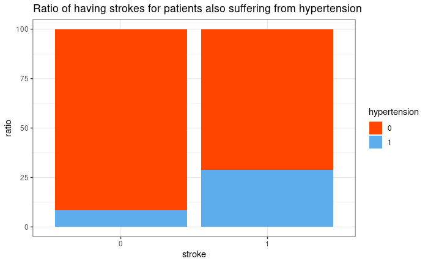

```r
ratio_barpplot("hypertension")
```

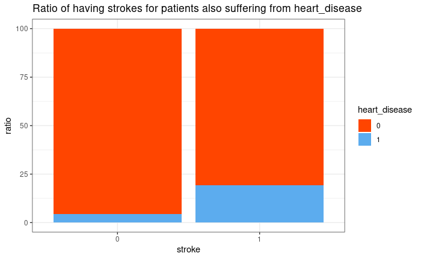

```r
ratio_barpplot("heart_disease")
```

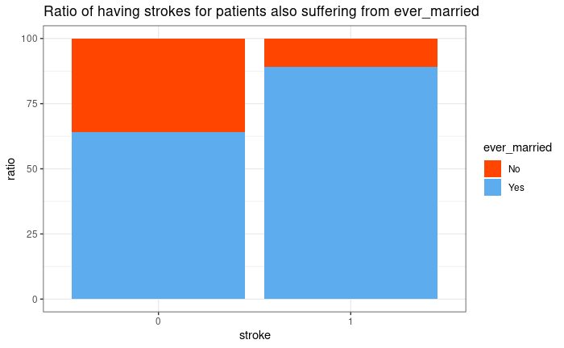

```r
ratio_barpplot("ever_married")
```

Predicting Stroke outcome

```r
install.packages("randomForest")
```

```r
library(randomForest)
```

```r
install.packages("caret")
library(caret)
```

```r
formula<-(stroke~gender+age+hypertension+heart_disease+ever_married+work_type+Residence_type+avg_glucose_level+bmi)
rf_clf<-randomForest(formula=formula,data=data)
pred<-predict(object=rf_clf, newdata=select(data, -stroke), type="class")
confusionMatrix(data=pred, reference=data$stroke)
```

```
Confusion Matrix and Statistics

          Reference
Prediction    0    1
         0 4699   27
         1    0  182

               Accuracy : 0.9945
                 95% CI : (0.992, 0.9964)
    No Information Rate : 0.9574
    P-Value [Acc > NIR] : < 2.2e-16

                  Kappa : 0.9281

 Mcnemar's Test P-Value : 5.624e-07

            Sensitivity : 1.0000
            Specificity : 0.8708
         Pos Pred Value : 0.9943
         Neg Pred Value : 1.0000
             Prevalence : 0.9574
         Detection Rate : 0.9574
   Detection Prevalence : 0.9629
      Balanced Accuracy : 0.9354

       'Positive' Class : 0
```

```r
# Central Limit Theorem
bmi<-data$bmi[data$stroke==0]
#hist(bmi, col="lightblue",breaks=40)
print(paste("Mean BMI of the total population is", round(mean(bmi),1)))
```

```
[1] "Mean BMI of the total population is 28.8"
```

```r
s<-2000
bmi_set1<-rep(0,20)
bmi_set2<-rep(0,200)
bmi_set3<-rep(0,2000)
for (i in 1:s){
  bmi_sample<-sample(bmi,size=20,replace=F)
  if (i<=2000){
    bmi_set3[i]<-mean(bmi_sample)
  }
  if(i<=200){
    bmi_set2[i]<-mean(bmi_sample)
  }
  if(i<=20){
    bmi_set1[i]<-mean(bmi_sample)
  }
}
```

```r
library(reshape2)
```

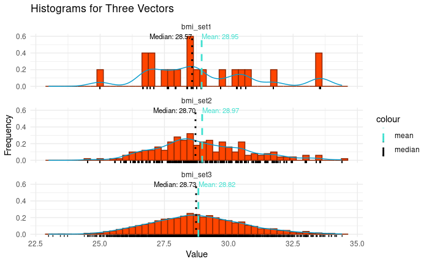

```r
# Combine into a single data frame
df <- data.frame(bmi_set1, bmi_set2, bmi_set3)
mean_vals <- sapply(df, mean)
median_vals <- sapply(df, median)

# Create data frames for mean and median
mean_df <- data.frame(variable = names(mean_vals), value = mean_vals)
median_df <- data.frame(variable = names(median_vals), value = median_vals)
# Melt the data
melted_df <- melt(df)
# Plot using ggplot2
ggplot(melted_df, aes(x=value)) +
  geom_histogram(aes(y=..density..), binwidth=0.25, bins=100, fill="orangered", color="orangered4", alpha=1) +
  geom_density(color="deepskyblue3") +
  geom_rug() +
  geom_vline(data=mean_df, aes(xintercept=value, color="mean"), linetype="dashed", size=1) +
  geom_vline(data=median_df, aes(xintercept=value, color="median"), linetype="dotted", size=1) +
  geom_text(data=mean_df, aes(x=value, label=sprintf("Mean: %.2f", value), y=Inf, hjust=0), vjust=1, size=3, color="turquoise") +
  geom_text(data=median_df, aes(x=value, label=sprintf("Median: %.2f", value), y=Inf, hjust=1), vjust=1, size=3, color="black") +
  facet_wrap(~variable, ncol=1) +
  scale_color_manual(values=c("mean"="turquoise", "median"="black")) +
  theme_minimal() +
  labs(title="Histograms for Three Vectors", x="Value", y="Frequency")
```

So, we can observe as the sample set is becoming larger and larger, the sampling distribution of the sample mean is having a normal or central tendency. And according to the Central Limit Theorem, mean of the sampling distribution of the sample mean is becoming equal to that of the actual population mean. 28.95 –> 28.97 –> 28.82 (whre, original population mean= 28.8)

```r
#Law of Large Numbers (LLN)
#converting [1,2] to [0,1] using levels
hyper<-as.numeric(levels(data$hypertension))[data$hypertension]
str(hyper)
```

```
 num [1:4908] 0 0 0 1 0 1 0 0 1 0 ...
```

```r
avg<-mean(hyper==1)
```

```r
samples<- 2000
set1<-sample(hyper, samples, replace=FALSE)
set2<-sample(hyper, samples, replace=FALSE)
set3<-sample(hyper, samples, replace=FALSE)
```

```r
xdel1<-rep(0,samples)
xdel2<-rep(0,samples)
xdel3<-rep(0,samples)
for (i in 1:samples){
  xdel1[i]<-mean(set1[1:i])
  xdel2[i]<-mean(set2[1:i])
  xdel3[i]<-mean(set3[1:i])
}
```

```r
# Create a sequence of indices for x-axis
x <- seq(1, samples, by=1)

# Plot the first vector
plot(x, avg-xdel1, type="l", col="red", ylim=c(min(avg-xdel1, avg-xdel2, avg-xdel3), max(avg-xdel1, avg-xdel2, avg-xdel3)), ylab="Error in Average", xlab="#samples", main="Error in average of three sample set")

# Add the second vector
lines(x, avg-xdel2, col="blue")
```

```r
# Add the third vector
lines(x, avg-xdel3, col="green")

# Add the horizontal line at y=0
abline(h=0, col="black", lty=2)  # lty=2 makes the line dashed
```

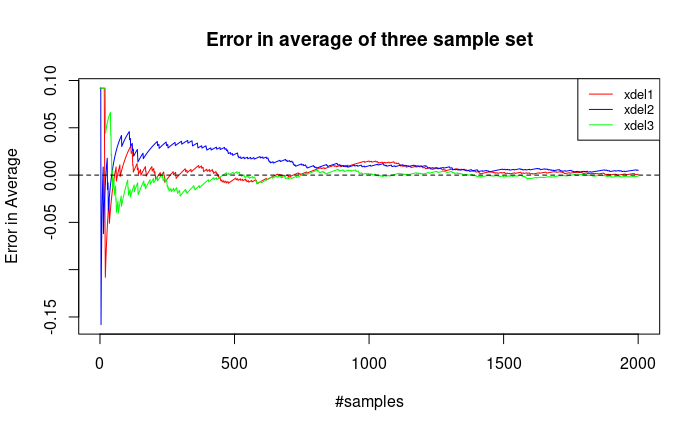

```r
# Add a legend
legend("topright", legend=c("xdel1", "xdel2", "xdel3"), col=c("red", "blue", "green"), lty=1, cex=0.8)
```

Hence, as the sample size become larger and larger the error in calculating ratio of people having hypertension trends to zero (a pure demonstration of Law of Large Numbers(LLN))

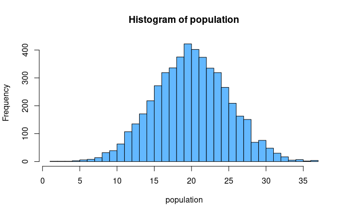

```r
#Confidence Intervals
population<-rnorm(5000, 20, 5)
hist(population, breaks=50, col="steelblue1")
```

```r
pop_mean=round(mean(population),3)
pop_sd=round(sd(population),3)
print(paste0("Population Mean ", pop_mean))
```

```
[1] "Population Mean 19.977"
```

```r
print(paste0("Population Std Err ", pop_sd))
```

```
[1] "Population Std Err 4.976"
```

```r
# constructing confidence interval:

# taking n=200 samples and trying toestimate the true population mean
n=200
samples<-sample(population, n, replace=FALSE)
samp_mean<-mean(samples)
# say, our claim is mean has changed.
# So, Null Hypothesis H_o=> mu = 19.977
# and, alternative Hypothesis H_a=> mu != 19.977

# for 95% CI:
alpha<- 0.05
quant<- 1-alpha/2
z<-qnorm(quant,lower.tail=TRUE) # calculating z-score from z-table
# using Z-statistic needs to know the true population std dev.
# assuming we know the true population std. dev (from previous step)
se<-pop_sd/sqrt(n)

upper_bound<-samp_mean + z*se
lower_bound<-samp_mean - z*se

hist(samples,breaks=20, col="orangered")
abline(v=upper_bound,lwd=4)
```

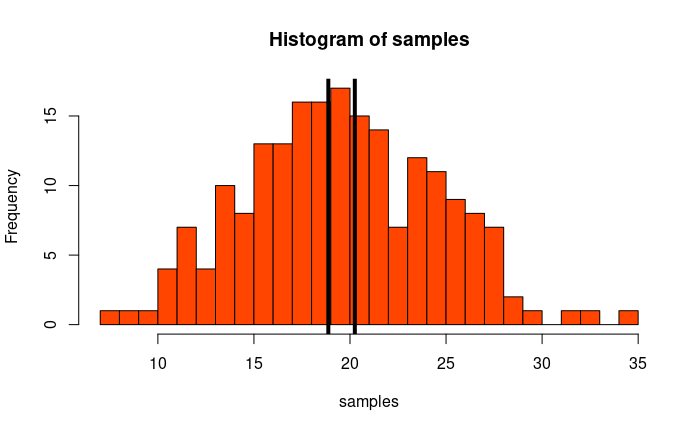

```r
abline(v=lower_bound, lwd=4)
```

```r
print(paste0("With 95% confidence we can say that population mean is in interval [", round(lower_bound,1), "; ", round(upper_bound,1), "]"))
```

```
[1] "With 95% confidence we can say that population mean is in interval [18.9; 20.3]"
```

```r
#using t-statistic
dff<- n-1
t<-qt(quant,dff)
se<-mean(samples)/sqrt(n)
upper_bound<-samp_mean + t*se
lower_bound<-samp_mean - t*se

hist(samples,breaks=20, col="orange")
abline(v=upper_bound,lwd=4)
```

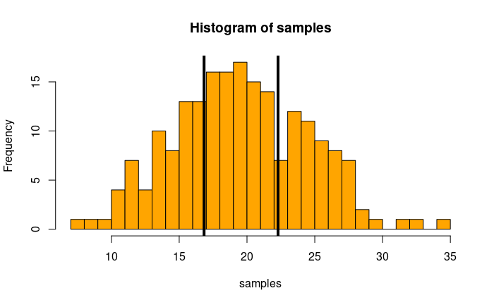

```r
abline(v=lower_bound, lwd=4)
```

```r
print(paste0("With 95% confidence we can say that population mean is in interval [", round(lower_bound,1), "; ", round(upper_bound,1), "]"))
```

```
[1] "With 95% confidence we can say that population mean is in interval [16.8; 22.3]"
```

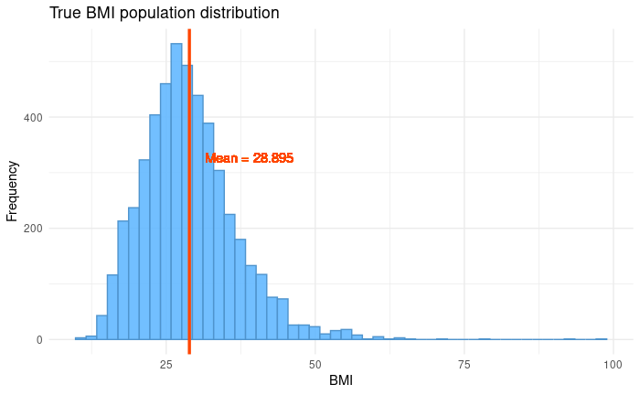

```r
all_bmi<- data$bmi
bmi_pop_mean<-round(mean(all_bmi),3)
p <- ggplot(data.frame(all_bmi), aes(x = all_bmi)) +
  geom_histogram(bins = 50, fill = "steelblue1",col="steelblue3", alpha = 0.9) +
  geom_vline(aes(xintercept = bmi_pop_mean), color = "orangered1", linetype = "solid", size = 1.2) +
  geom_text(aes(x = bmi_pop_mean+10,y=300, label = paste("Mean =", bmi_pop_mean)), vjust = -1, hjust = 0.5, color = "orangered1")+
  xlab("BMI") +
  ylab("Frequency") +
  theme_minimal()+
  labs(title="True BMI population distribution")

# Show the plot
print(p)
```

```r
print(paste0("True population mean= ", bmi_pop_mean))
```

```
[1] "True population mean= 28.895"
```

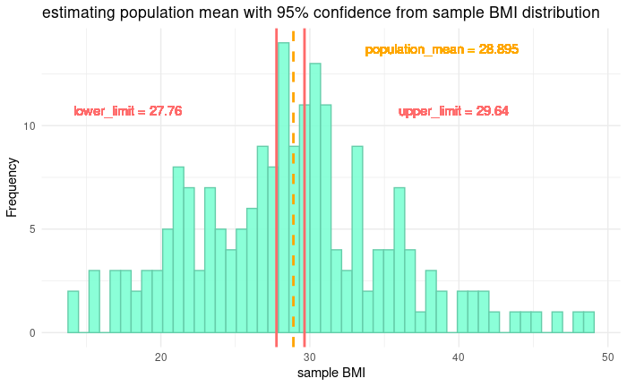

```r
# 95% CI on bmi
sample_size<-200
samp_bmi<-sample(all_bmi, sample_size)
samp_bmi_mean<-round(mean(samp_bmi),3)
samp_bmi_sd<-sd(samp_bmi)
alpha<-0.05# as Confidence level= 95%
quant<-(1-alpha/2)
df_bmi<-sample_size-1
t_score<-qt(quant,df_bmi)
bmi_conf_upper<-samp_bmi_mean + t_score*(samp_bmi_sd/sqrt(sample_size))
bmi_conf_lower<-samp_bmi_mean - t_score*(samp_bmi_sd/sqrt(sample_size))

q <- ggplot(data.frame(samp_bmi), aes(x = samp_bmi)) +
  geom_histogram(bins = 50, fill = "aquamarine1",col="aquamarine3", alpha = 0.9) +
  geom_vline(aes(xintercept = bmi_conf_upper), color = "indianred1", linetype = "solid", size = 1) +
  geom_text(aes(x = bmi_conf_upper+10,y=10, label = paste("upper_limit =", round(bmi_conf_upper,3))), vjust = -1, hjust = 0.5, color = "indianred1") +
  geom_vline(aes(xintercept = bmi_conf_lower), color = "indianred1", linetype = "solid", size = 1) +
  geom_text(aes(x = bmi_conf_lower-10,y=10, label = paste("lower_limit =", round(bmi_conf_lower,3))), vjust = -1, hjust = 0.5, color = "indianred1") +
  geom_vline(aes(xintercept = bmi_pop_mean), color = "orange", linetype = "dashed", size = 1) +
  geom_text(aes(x = bmi_pop_mean+10,y=13, label = paste("population_mean =", bmi_pop_mean)), vjust = -1, hjust = 0.5, color = "orange") +
  xlab("sample BMI") +
  ylab("Frequency") +
  theme_minimal()+
  labs(title="estimating population mean with 95% confidence from sample BMI distribution ")

# Show the plot
print(q)
```

```r
print(paste0("sample population mean= ", samp_bmi_mean))
```

```
[1] "sample population mean= 28.7"
```

```r
print(paste0("With 95% confidence we can say that population mean is in interval [", round(bmi_conf_lower,1), "; ", round(bmi_conf_upper,1), "]"))
```

```
[1] "With 95% confidence we can say that population mean is in interval [27.8; 29.6]"
```

```r
sample_n(data,10)
```

| id | gender | age | hypertension | heart_disease | ever_married | work_type | Residence_type | avg_glucose_level | bmi | smoking_status | stroke |
| --- | --- | --- | --- | --- | --- | --- | --- | --- | --- | --- | --- |
| 43803 | Female | 64 | 0 | 0 | Yes | Private | Urban | 65.63 | 33.5 | smokes | 0 |
| 66310 | Male | 54 | 0 | 0 | Yes | Self-employed | Rural | 138.47 | 31.5 | never smoked | 0 |
| 69089 | Female | 40 | 0 | 0 | Yes | Private | Rural | 83.30 | 32.0 | smokes | 0 |
| 54962 | Female | 27 | 0 | 0 | No | Private | Urban | 82.05 | 21.0 | Unknown | 0 |
| 58508 | Female | 18 | 0 | 0 | No | Govt_job | Rural | 112.33 | 23.2 | formerly smoked | 0 |
| 38320 | Male | 45 | 1 | 0 | Yes | Private | Rural | 136.20 | 23.8 | Unknown | 0 |
| 38242 | Female | 78 | 0 | 1 | Yes | Self-employed | Rural | 88.90 | 34.3 | Unknown | 0 |
| 54401 | Male | 80 | 0 | 1 | Yes | Self-employed | Urban | 252.72 | 30.5 | formerly smoked | 1 |
| 62019 | Male | 54 | 0 | 0 | Yes | Govt_job | Rural | 87.85 | 31.1 | smokes | 1 |
| 37290 | Male | 80 | 0 | 0 | Yes | Self-employed | Rural | 236.84 | 26.8 | never smoked | 0 |

```r
# t- test
str<-data$age[data$stroke==1]
no_str<-data$age[data$stroke==0]
str_df <- data.frame(str)

# Create a data frame for individuals without stroke
no_str_df <- data.frame(no_str)

# Summarise the data frame for individuals with stroke
summary_str <- summarise(str_df,
                         mean_age = mean(str, na.rm = TRUE),
                         median_age = median(str, na.rm = TRUE),
                         sd_age = sd(str, na.rm = TRUE),
                         min_age = min(str, na.rm = TRUE),
                         max_age = max(str, na.rm = TRUE),
                         count = nrow(str_df))

# Summarise the data frame for individuals without stroke
summary_no_str <- summarise(no_str_df,
                            mean_age = mean(no_str, na.rm = TRUE),
                            median_age = median(no_str, na.rm = TRUE),
                            sd_age = sd(no_str, na.rm = TRUE),
                            min_age = min(no_str, na.rm = TRUE),
                            max_age = max(no_str, na.rm = TRUE),
                            count = nrow(no_str_df))
```

```r
# Print summaries
print(summary_str)
```

| mean_age | median_age | sd_age | min_age | max_age | count |
| --- | --- | --- | --- | --- | --- |
| 67.71292 | 70 | 12.40285 | 14 | 82 | 209 |

```r
print(summary_no_str)
```

| mean_age | median_age | sd_age | min_age | max_age | count |
| --- | --- | --- | --- | --- | --- |
| 41.76381 | 43 | 22.26931 | 0.08 | 82 | 4699 |

```r
NA
```

```r
mean(str)-mean(no_str)
```

```
[1] 25.94911
```

So, we see here the average age difference = 25.949 our hypothesis: H_o : there is no age difference, mu= 0 H_a : there is a difference, mu != 0

```r
len_str<- length(str)
var_str<-var(str)


len_no_str<- length(no_str)
var_no_str<-var(no_str)

diff_mean<- mean(no_str)-mean(str)

se<-sqrt(var_str/len_str + var_no_str/len_no_str)


alpha<-0.05
quant<-(1-alpha/2)
df_age<-len_str+len_no_str-2

t_age<-qt(quant,df_age)

upper_limit<- diff_mean+t_age*se
lower_limit<- diff_mean-t_age*se

print(paste0("With 95% confidence we can say that population mean is in interval [", round(upper_limit,1), "; ", round(lower_limit,1), "]"))
```

```
[1] "With 95% confidence we can say that population mean is in interval [-24.2; -27.7]"
```

As, the confidence interval doesn’t include 0 rather is way below 0. So, with 95% confidence we can say that the age difference in between people having stroke and not having stroke is significant. So, we reject our Null Hypothesis (H_o) and accept alternative hypothesis (H_a)

```r
# alternative way:
t_age<- (diff_mean - 0)/se
print(paste("t score",t_age))
```

```
[1] "t score -28.2863881984247"
```

```r
p_value <- pt(-abs(t_age), df_age, lower.tail = TRUE)
print(paste("Probability of having a t_score of that is:", p_value))
```

```
[1] "Probability of having a t_score of that is: 1.70630768710462e-163"
```

Here, P_value << alpha : reject H_o accept H_a Hence, the age difference is significant.

```r
#using R library

t.test(age~stroke, data=data, var.equal=FALSE, paired=FALSE,conf.level=0.95)
```

```
    Welch Two Sample t-test

data:  age by stroke
t = -28.286, df = 271.68, p-value < 2.2e-16
alternative hypothesis: true difference in means between group 0 and group 1 is not equal to 0
95 percent confidence interval:
 -27.75517 -24.14305
sample estimates:
mean in group 0 mean in group 1
       41.76381        67.71292
```

```r
# using F statistic
var.test(age~stroke, data= data)
```

```
    F test to compare two variances

data:  age by stroke
F = 3.2238, num df = 4698, denom df = 208, p-value < 2.2e-16
alternative hypothesis: true ratio of variances is not equal to 1
95 percent confidence interval:
 2.624126 3.890156
sample estimates:
ratio of variances
          3.223819
```

```r
install.packages("bootstrap")
```

```r
library(bootstrap)
```

```r
bmi_len<- length(bmi)
bias_var=function(x){
  n=length(x)
  (n-1)*var(x)/n
}
jackknife(bmi, bias_var)
```

[output not shown]

[output cut: 73 more lines]

B O 0 T S T R A P P I N G

Statistical Rigor: Estimation of Sampling Distribution: It allows for the empirical estimation of the sampling distribution of almost any statistic, providing a way to estimate standard errors, confidence intervals, and other distributional characteristics. Bias and Variance Estimation: Bootstrapping can help in estimating the bias and variance of a statistic, providing more information than just a point estimate.

Flexibility: Model Validation: It can be used for model validation and for diagnosing the fit of a model. Hypothesis Testing: Bootstrapping can be adapted for hypothesis testing, especially for tests where the analytic form is complex or not available. Small Sample Performance Small Sample Size: Bootstrapping can be particularly useful when your sample size is small, making it difficult to make reliable parametric assumptions.

Limitations and Caveats: It’s important to note that while bootstrapping is powerful, it is not without its limitations. For example:

It may not perform well for data that has a complex dependence structure (e.g., time series data). Bootstrapping provides an approximation, and the quality of this approximation depends on the actual sample size and the underlying distribution.

```r
#Bootstrapping
sample_size<- 500
samples<- 10000
bmi_samp<- sample(bmi, sample_size, replace = FALSE)
print(paste("Mean of the sampled true population: ",mean(bmi_samp)))
```

```
[1] "Mean of the sampled true population:  28.8608"
```

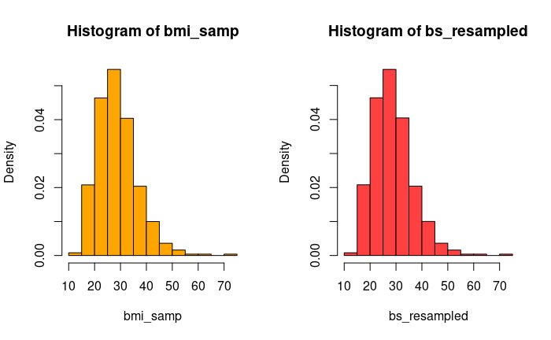

```r
bs_resampled<-matrix(sample(bmi_samp, sample_size*samples,replace = TRUE),nrow=samples, ncol=sample_size)
par(mfcol=c(1,2))
hist(bmi_samp,probability=TRUE,breaks=20, col="orange")
hist(bs_resampled,probability=TRUE, breaks=20, col="brown1")
```

Here, both distribution is looking identical. And it was expected. Cause we were trying to emulate the left one ((assumed)true distribution(though it was sampled from total population, just assume that it is the true distribution)) by sampling(bootsrapping) many times and got that on the right histogram.

```r
#calculating mean for each row
bs_mean<-rowMeans(bs_resampled)

hist(bs_mean,probability = TRUE, breaks=10, col="steelblue1")
abline(v=mean(bmi_samp),col="orange",lwd=3)
```

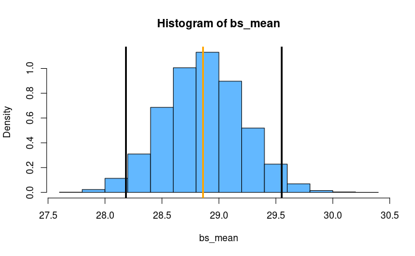

```r
abline(v=quantile(bs_mean,c(.025,0.975)), lwd=3)# 95% confidence interval
```

```r
print(paste("Std. error: ", round(sd(bs_mean),3)))
```

```
[1] "Std. error:  0.347"
```

The standard deviation of this bootstrapped distribution gives us an idea of how much mean(statistic) would vary if we were to draw many different samples from the population, thereby acting as an estimate of the standard error.

```r
# getting confidence interval in every possible way:
# say, we want to see the prevalence of hypertention in our population
n=200
hyper<-sample(data$hypertension,n)
hyper_prop<-length(hyper[hyper==1])
print(binom.confint(hyper_prop, n=n, conf.level = 0.95, methods = "all"))
```

|  | method | x | n | mean | lower | upper |
| --- | --- | --- | --- | --- | --- | --- |
| 1 | agresti-coull | 15 | 200 | 0.07500000 | 0.04513470 | 0.1208838 |
| 2 | asymptotic | 15 | 200 | 0.07500000 | 0.03849649 | 0.1115035 |
| 3 | bayes | 15 | 200 | 0.07711443 | 0.04214978 | 0.1145008 |
| 4 | cloglog | 15 | 200 | 0.07500000 | 0.04390569 | 0.1168872 |
| 5 | exact | 15 | 200 | 0.07500000 | 0.04258280 | 0.1206842 |
| 6 | logit | 15 | 200 | 0.07500000 | 0.04571734 | 0.1206670 |
| 7 | probit | 15 | 200 | 0.07500000 | 0.04480999 | 0.1186709 |
| 8 | profile | 15 | 200 | 0.07500000 | 0.04387245 | 0.1169318 |
| 9 | lrt | 15 | 200 | 0.07500000 | 0.04386730 | 0.1169304 |
| 10 | prop.test | 15 | 200 | 0.07500000 | 0.04405794 | 0.1230217 |

[output cut: 1 more lines]

That means, with 95% confidence we can say, roughly [4% to 12%] of the population have hypertension.